[interactive chart not shown]

# Advanced Clustering Techniques

#### **About the Datasets**

The first dataset, titled *"Dentition of Mammals"*, originates from the book **Clustering Algorithms** by John Hartigan (Wiley, 1975). This dataset contains dentition patterns of various mammals, specifically designed for exploring biological traits using clustering techniques. It includes 8 key dental traits for each animal, capturing the number of incisors, canines, premolars, and molars in both the top and bottom jaws.

Each row in the mammal dataset represents a different species, identified by its "Name". The tooth pattern is broken down into columns reflecting the dental structure.

The second dataset, titled *"s1"*, contains Gaussian clusters and was extracted from the “Clustering Basic Benchmark” dataset by P. Fränti and S. Sieranoja ([source](http://cs.joensuu.fi/sipu/datasets/)). It includes 5,000 observations, each with two-dimensional coordinates, specifically designed for clustering algorithm benchmarks. This Gaussian data allows for the testing and comparison of clustering methods, such as K-Means and DBSCAN, and is useful for identifying strengths and limitations in separating densely packed or overlapping clusters.

#### **Libraries Used:** factoextra, cluster, dendextend, ggplot2

#### **Key Findings**

By applying clustering techniques, distinct animal groups were identified, including small herbivores, large carnivores, and omnivores. K-Means effectively grouped animals based on physical traits and dietary habits, highlighting how these factors influence natural species groupings. For the Gaussian dataset, DBSCAN accurately captured clusters that were challenging for K-Means, particularly in cases of densely packed or irregularly shaped groups.

#### **Data Visualizations**

Cluster plots were used to visualize the groups formed by K-Means and DBSCAN. In the animal dataset, K-Means plots illustrated how animals with similar traits were clustered together. For the Gaussian dataset, DBSCAN visualizations clearly highlighted its success in separating dense, overlapping clusters, which K-Means struggled to distinguish.

#### **Conclusions**

The project showcased effective data preprocessing and clustering techniques, revealing insights into natural groupings based on physical traits in animals. DBSCAN proved highly effective on the Gaussian dataset, accurately identifying clusters without the shape and density limitations of K-Means, which helped refine our understanding of cluster differentiation between these two datasets.

Advanced Clustering Techniques

Sections

- Unlocking Patterns in Tooth Data (Dentition of Mammals)
- Exploring K-Means and DBSCAN for Clustering Gaussian Data

## Clustering

Before diving into how I prepared the data for clustering, let’s first break down what **clustering** is and why it’s so valuable.

#### What is Clustering?

Clustering is a type of *unsupervised learning* in machine learning that helps group data points into clusters (or groups) based on their similarities. It doesn’t require labeled data or predefined categories. Instead, it analyzes the patterns in the data and groups together points that are more alike. It’s like sorting puzzle pieces into piles by matching their edges, colors, and patterns.

For example:

- In biology, clustering can help group species based on physical traits or genetic similarities.
- In marketing, clustering helps companies group customers by similar behavior, allowing targeted campaigns.
- In social media, clustering can help detect communities within networks by grouping users who interact more frequently.

### **Unlocking Patterns in Tooth Data (Dentition of Mammals)**

For my project, clustering will help me discover groups of mammals with similar tooth patterns, without me telling the algorithm how to classify them. It's a powerful way to unlock hidden patterns in the data.

#### Types of Teeth

The image below provides a visual representation of the various types of teeth, which are categorized in the dataset. It helps illustrate the different tooth types, including incisors, canines, premolars, and molars, for both the upper and lower jaw.

[figure not shown]

Now that you have a basic understanding of the data collected, let’s jump into my project and talk about the process I took to prepare the data. Here’s a simple breakdown of the steps I took:

**Step 1: Removing the name field** – Each mammal has a unique name, but this doesn’t help when clustering. The goal of clustering is to find similarities, and since every name is different, it would just create unnecessary noise in the data. I removed the names so I could focus on what really matters: the tooth pattern data.

**Step 2: Handling correlated features** – When I examined the dataset, I noticed that “top canines (C)” and “bottom canines (c)” had very similar values. This makes sense because top and bottom canines typically grow in proportion to one another. Including both could cause redundant information to skew the clustering process, so I chose to remove one (I picked “bottom canines” since the top canines usually have more distinct features in animals). For the same reason, I also removed “bottom molars (m)” and “bottom premolars (p)” as they exhibited similar correlations with their corresponding top teeth.

Highly correlated features like this can confuse the algorithm, making it harder to detect the true patterns in the data. By removing one, I made the analysis cleaner and more reliable.

**Step 3: No need for standardization** – Often, data needs to be standardized (or scaled) to make sure no single feature dominates the analysis due to differences in magnitude. In this case, all the tooth features had similar scales, so I didn’t need to do any scaling.

```r
library(factoextra)
```

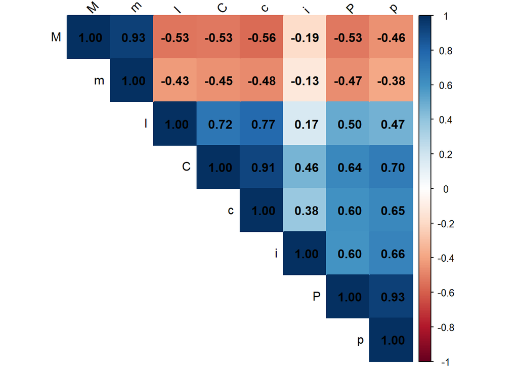

```r
library(corrplot)
library(factoextra)
library(RColorBrewer)
working_directory <- getwd()
setwd(working_directory)
mammals_old <- read.table("file19.txt", header = TRUE, skip = 20)


# the tooth pattern
#
#(I) the number of top incisors,
#(i) bottom incisors,
#(C) top canines,
#(c) bottom canines,
#(P) top premolars,
#(p) bottom premolars,
#(M) top molars
#(m) bottom molars.

correlation_matrix <- cor(mammals_old[2:9])
corrplot(correlation_matrix, method = "color", type = "upper", order = "hclust", addCoef.col = "black", tl.col = "black", tl.srt = 45)
```

```r
mammals<- mammals_old[,-c(5,7,9)]

print(mammals)
```

Note: Name is removed in clustering, but only by not referencing the first column in later processes.

```
##     Name            I i C P M
  ## 1        Opossum 5 4 1 3 4
## 2  Hairy tail mole 3 3 1 4 3
## 3      Common mole 3 2 1 3 3
## 4   Star nose mole 3 3 1 4 3
## 5        Brown bat 2 3 1 3 3
## 6  Silver hair bat 2 3 1 2 3
## 7        Pigmy bat 2 3 1 2 3
## 8        House bat 2 3 1 1 3
## 9          Red bat 1 3 1 2 3
## 10       Hoary bat 1 3 1 2 3
## 11   Lump nose bat 2 3 1 2 3
## 12       Armadillo 0 0 0 0 8
## 13            Pika 2 1 0 2 3
## 14 Snowshoe rabbit 2 1 0 3 3
```

[output cut: 52 more lines]

#### Finding The Best Number of Clusters

After performing the silhouette method to determine the optimal number of clusters, I found that 9 clusters provided the best separation for the data. The silhouette plot clearly indicated that 9 clusters offered the highest average silhouette width (a measure of how similar points are to their own cluster compared to other clusters), ensuring well-separated and distinct groups in the dataset.

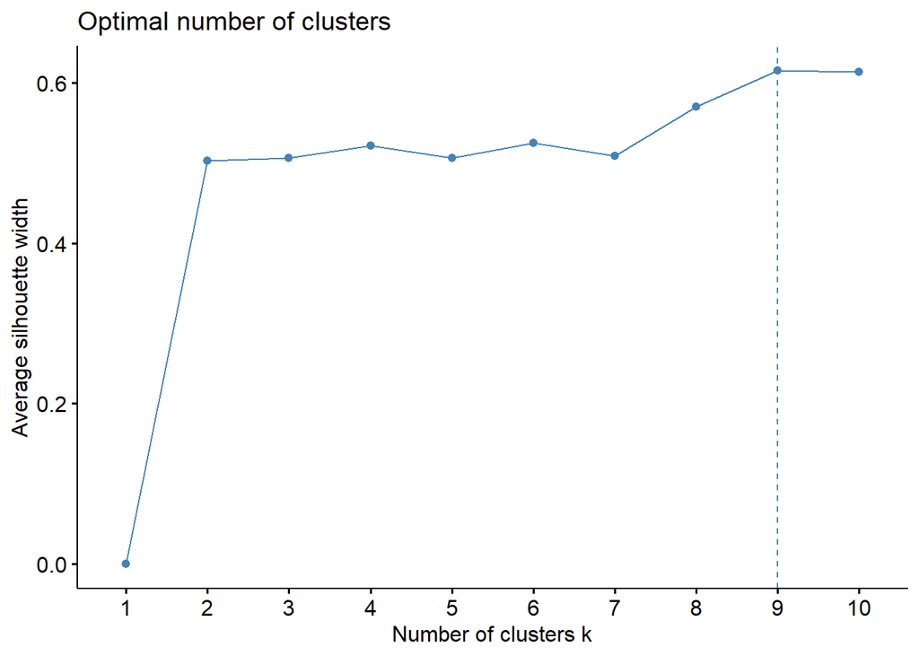

```r
fviz_nbclust(mammals[,-1], kmeans, method = "silhouette")
```

#### Clustering

In this step, I am using a clustering algorithm called K-Means to group the animals into 9 different clusters. The goal of K-Means is to find clusters of animals that are similar based on their features.

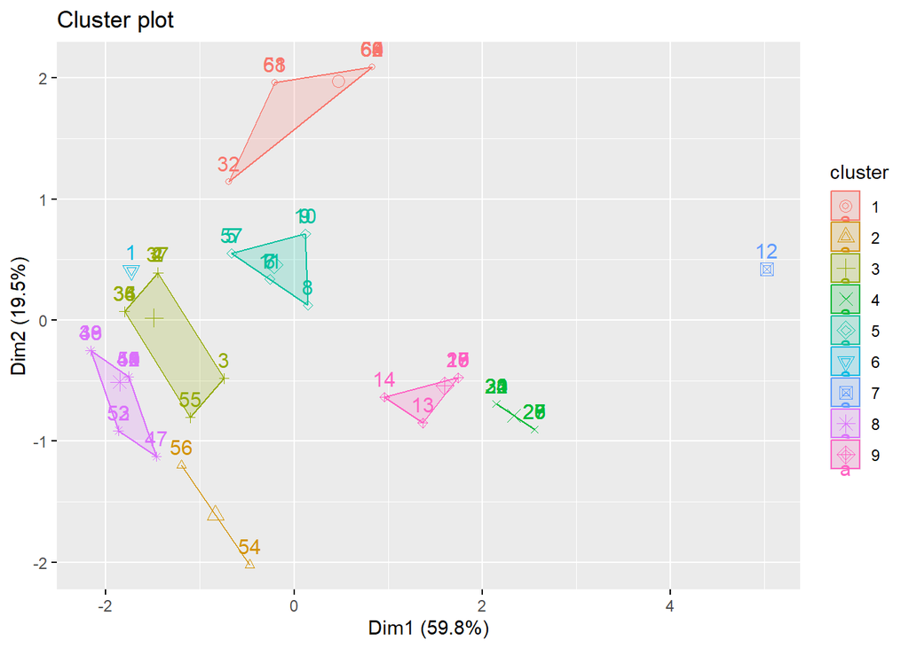

```r
km.mammals <- kmeans(mammals[,-1], 9, nstart = 10)
fviz_cluster(km.mammals, mammals[,-1])
```

```r
animal_clusters <- data.frame(Name = animal_names, Cluster = km.mammals$cluster)

cluster_one <- animal_clusters[which(km.mammals$cluster == 1), ]
cluster_two <- animal_clusters[which(km.mammals$cluster == 2), ]
cluster_three <- animal_clusters[which(km.mammals$cluster == 3), ]
cluster_four <- animal_clusters[which(km.mammals$cluster == 4), ]
cluster_five <- animal_clusters[which(km.mammals$cluster == 5), ]
cluster_six <- animal_clusters[which(km.mammals$cluster == 6), ]
cluster_seven <- animal_clusters[which(km.mammals$cluster == 7), ]
cluster_eight <- animal_clusters[which(km.mammals$cluster == 8), ]
cluster_nine <- animal_clusters[which(km.mammals$cluster == 9), ]


cat(" Number of observations in Cluster 1: ", nrow(cluster_one), "\n",
    "Number of observations in Cluster 2: ", nrow(cluster_two), "\n",
    "Number of observations in Cluster 3: ", nrow(cluster_three), "\n",
    "Number of observations in Cluster 4: ", nrow(cluster_four), "\n",
    "Number of observations in Cluster 5: ", nrow(cluster_five), "\n",
    "Number of observations in Cluster 6: ", nrow(cluster_six), "\n",
    "Number of observations in Cluster 7: ", nrow(cluster_seven), "\n",
    "Number of observations in Cluster 8: ", nrow(cluster_eight), "\n",
    "Number of observations in Cluster 9: ", nrow(cluster_nine), "\n")
```

```
##  Number of observations in Cluster 1:  10
##  Number of observations in Cluster 2:  2
##  Number of observations in Cluster 3:  9
##  Number of observations in Cluster 4:  11
##  Number of observations in Cluster 5:  8
##  Number of observations in Cluster 6:  1
##  Number of observations in Cluster 7:  1
##  Number of observations in Cluster 8:  16
##  Number of observations in Cluster 9:  8
```

#### Sum of Squared Errors

```r
km.mammals <- kmeans(mammals[,-1], 9, nstart = 10)
print("Total SSE:")
```

```
## [1] "Total SSE:"
```

```r
print(km.mammals$totss)
```

```
## [1] 380.5455
```

#### K-Means Clustering Summary

The K-Means algorithm grouped the animals into 9 clusters of varying sizes. The clusters range from 1 to 15 animals each.

The algorithm also shows how well the data fits within each cluster by providing the "within cluster sum of squares" (how tightly packed the data points are within each cluster). The ratio of between-cluster variation to total variation is 91.7%, which means the clusters are well-separated and distinct from each other.

In summary, the clustering has divided the data meaningfully, with each group having its own set of average values, and most of the variation in the data is explained by the clustering structure.

```r
print(km.mammals)
```

```
## K-means clustering with 9 clusters of sizes 8, 15, 10, 8, 11, 1, 10, 2, 1
##
## Cluster means:
##      I        i   C         P        M
## 1 1.25 1.000000 0.0 2.1250000 3.000000
## 2 3.00 2.733333 1.0 3.8666667 1.866667
## 3 3.00 2.900000 1.0 3.0000000 1.000000
## 4 1.75 3.000000 1.0 2.1250000 3.000000
## 5 1.00 1.000000 0.0 0.5454545 3.000000
## 6 0.00 0.000000 0.0 0.0000000 8.000000
## 7 0.10 3.900000 0.3 3.1000000 3.000000
## 8 1.50 0.500000 1.0 3.5000000 0.500000
## 9 5.00 4.000000 1.0 3.0000000 4.000000
##
## Clustering vector:
##  [1] 9 2 2 2 4 4 4 4 4 4 4 6 1 1 1 1 1 1 1 1 5 5 5 5 5 5 5 5 5 5 5 7 2 2 2 2 2 2
## [39] 2 3 3 3 2 3 3 2 3 3 3 3 3 2 2 8 2 8 4 7 7 7 7 7 7 7 7 7
##
## Within cluster sum of squares by cluster:
## [1]  2.375000 14.400000  0.900000  4.375000  2.727273  0.000000  4.800000
## [8]  2.000000  0.000000
##  (between_SS / total_SS =  91.7 %)
##
## Available components:
##
## [1] "cluster"      "centers"      "totss"        "withinss"     "tot.withinss"
## [6] "betweenss"    "size"         "iter"         "ifault"
```

#### Cluster One

```r
print(cluster_one[, 1])
```

```
##  [1] "Coyote"         "Elk"            "Deer"           "Moose"
##  [5] "Reindeer"       "Antelope"       "Bison"          "Mountain goat"
##  [9] "Musk ox"        "Mountain sheep"
```

#### Cluster Two

```r
print(cluster_two[, 1])
```

```
## [1] "Walrus"        "Elephant seal"
```

#### Cluster Three

Cluster Three contains burrowing mammals like moles and larger predators such as the Wolf and Bear. These species share similar dentition patterns in terms of incisors and canines, which suggests some overlap in their foraging or predatory behaviors. However, the presence of larger predators like the Wolf and Bear, alongside small mammals like moles could indicate potential outliers, as their diets and lifestyles are significantly different, despite the dentition similarities.

```r
print(cluster_three[, 1])
```

```
## [1] "Hairy tail mole" "Common mole"     "Star nose mole"  "Wolf"
## [5] "Fox"             "Bear"            "Civet cat"       "Raccoon"
## [9] "Grey seal"
```

#### Cluster Four

This cluster is dominated by small rodents such as the Gray Squirrel and Pocket Gopher. Their dental traits reflect adaptations for gnawing, with prominent incisors and simplified molar structures. No clear outliers exist in this group, as the species share similar ecological niches and feeding habits.

```r
print(cluster_four[, 1])
```

```
##  [1] "Gray squirrel" "Fox squirrel"  "Pocket gopher" "Kangaroo rat"
##  [5] "Pack rat"      "Field mouse"   "Muskrat"       "Black rat"
##  [9] "House mouse"   "Porcupine"     "Guinea pig"
```

#### Cluster Five

Cluster Five includes various bat species, known for their specialized dentition for diverse diets. The Peccary, however, stands out as a potential outlier in this group. While bats share traits suited for flying and nocturnal foraging, the Peccary is a terrestrial, hoofed mammal with a completely different diet and dentition. Its inclusion in this cluster might suggest convergence in specific dental traits but still marks it as an outlier due to its vastly different biology.

```r
print(cluster_five[, 1])
```

```
## [1] "Brown bat"       "Silver hair bat" "Pigmy bat"       "House bat"
## [5] "Red bat"         "Hoary bat"       "Lump nose bat"   "Peccary"
```

#### Cluster Six

The Opossum is the sole member of this cluster, indicating its unique combination of dentition traits. This reflects its omnivorous diet and marsupial nature, which likely set it apart from all other species in the dataset.

```r
print(cluster_six[, 1])
```

```
## [1] "Opossum"
```

#### Cluster Seven

The Armadillo is also a solitary member in Cluster Seven, reflecting its distinct dentition, adapted for an insectivorous diet. Its highly specialized dental traits set it apart from other mammals, which is why it stands alone.

```r
print(cluster_seven[, 1])
```

```
## [1] "Armadillo"
```

#### Cluster Eight Review

This cluster groups together carnivorous mammals such as the Marten, Jaguar, and Wolverine, along with semi-aquatic species like the River Otter, Sea Otter, Fur Seal, and Sea Lion. These animals share dental traits such as well-developed canines and fewer premolars and molars, indicating their adaptation to predatory lifestyles. The mix of land and marine species suggests that their dentition is specialized for hunting and consuming a variety of prey, whether on land or in water.

While the cluster makes sense from a dentition perspective, it’s worth noting the diversity in habitats. Semi-aquatic mammals like the Sea Otter and Sea Lion might appear as potential outliers given their different ecological environments, but their dental structures align with the broader carnivorous adaptations seen in this group.

```r
print(cluster_eight[, 1])
```

```
##  [1] "Marten"      "Fisher"      "Weasel"      "Mink"        "Ferrer"
##  [6] "Wolverine"   "Badger"      "Skunk"       "River otter" "Sea otter"
## [11] "Jaguar"      "Ocelot"      "Cougar"      "Lynx"        "Fur seal"
## [16] "Sea lion"
```

#### Cluster Nine

Cluster Nine includes small herbivores such as the Pika, Beaver, and Groundhog. Their dental patterns, suited to gnawing and grinding plants, are highly similar. No outliers appear in this group, as the species share both environmental adaptations and dietary needs.

```r
print(cluster_nine[,1])
```

```
## [1] "Pika"            "Snowshoe rabbit" "Beaver"          "Marmot"
## [5] "Groundhog"       "Prairie Dog"     "Ground Squirrel" "Chipmunk"
```

### **Exploring K-Means and DBSCAN for Clustering Gaussian Data**

In this project, I’ll compare two clustering methods—K-Means and DBSCAN—on a Gaussian dataset to explore the trade-offs between them. While K-Means is a commonly used clustering algorithm, it has limitations with datasets that contain clusters of varied shapes or densities. This dataset, `s1.csv`, has clusters that may not be spherical or evenly spaced, which can be challenging for K-Means to accurately classify.

#### Why DBSCAN?

DBSCAN is a great fit for this dataset because it excels where other methods, like K-Means, sometimes struggle—especially with clusters that aren’t perfectly round or separated by clear boundaries. Unlike K-Means, which relies on pre-defined clusters, DBSCAN focuses on finding regions of high density and can handle clusters of varying shapes and densities. This flexibility makes DBSCAN perfect for real-world data where clusters may not be cleanly separated.

#### How DBSCAN Works

DBSCAN works by focusing on two key settings:

- **Epsilon (ε)**: This is the distance around each point that DBSCAN will search to find neighbors. Points within this radius are considered part of the same cluster.
- **MinPts**: This is the minimum number of points needed within a given radius (ε) to form a dense region, which then becomes a cluster.

The algorithm starts by picking a point and looking within ε to see if it finds enough neighboring points to meet the `MinPts` requirement. If it does, this point is a “core” point, and it starts forming a cluster. If it doesn’t, it’s marked as “noise” but could still be included in another cluster if it falls within the radius of a different core point. This process continues until every point is either part of a cluster or marked as noise.

#### Loading Libraries and Preparing the Data

First, I loaded the `dbscan` and `fpc` libraries, which provide key tools for DBSCAN clustering and cluster analysis. After loading the dataset `s1.csv` with `read.csv`, I used `summary` to analyze the ranges of the `x` and `y` variables.

The summary showed a wide range in values for both `x` (19,835 to 961,951) and `y` (51,121 to 970,756), confirming the need for scaling to avoid biased clustering results. I applied `scale()` to standardize both variables, making the data ready for clustering.

```r
library(dbscan)
library(fpc)
s1 <- read.csv("s1.csv", header = TRUE)
summary(s1)
```

```
##        x                y
##  Min.   : 19835   Min.   : 51121
##  1st Qu.:320353   1st Qu.:320108
##  Median :505339   Median :526260
##  Mean   :514938   Mean   :494709
##  3rd Qu.:786229   3rd Qu.:713714
##  Max.   :961951   Max.   :970756
```

```r
s1.scaled <- scale(s1)
```

#### Visualizing and Identifying Clusters

After loading the data, I plotted both the original dataset (`s1`) and the scaled dataset (`s1.scaled`) to observe clustering patterns visually.

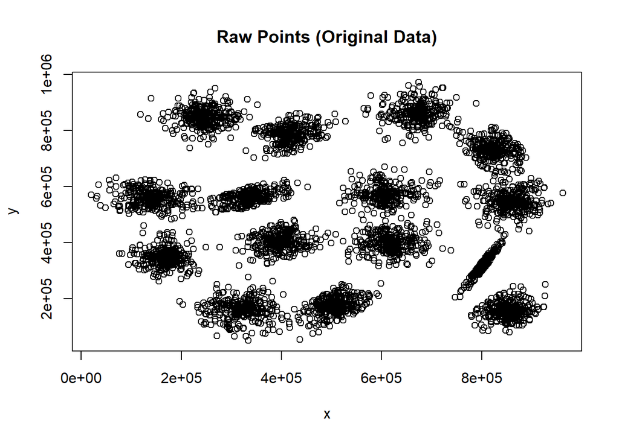

```r
plot(s1, main = "Raw Points (Original Data)")
```

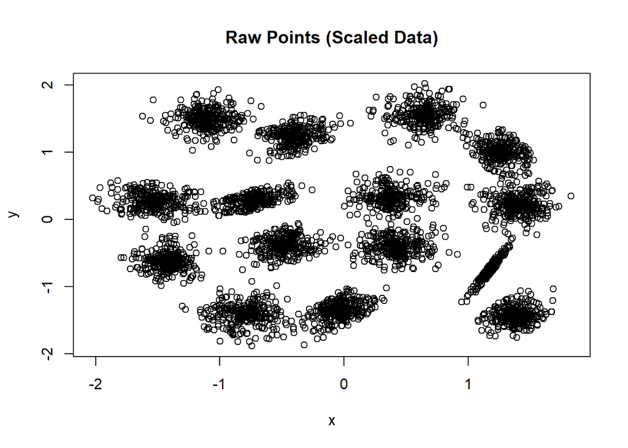

```r
# Plot for the scaled dataset (s1.scaled)
plot(s1.scaled, main = "Raw Points (Scaled Data)")
```

#### Determining the Optimal Number of Clusters with K-means

To determine the optimal number of clusters with k-means, I used two methods on the scaled dataset: the `wss` (within-cluster sum of squares) and `silhouette` methods. The `wss` method suggested 4 clusters as optimal, marked by a vertical line at 4. However, the `silhouette` method indicated 19 clusters as optimal.

This difference suggests a range to consider for further analysis, and I’ll explore both options before deciding on the most meaningful clustering pattern.

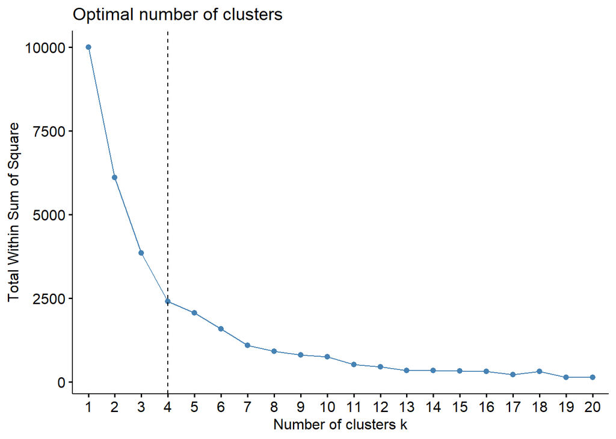

```r
fviz_nbclust(s1.scaled, kmeans, method = "wss", k.max = 20)  + geom_vline(xintercept = 4, linetype = 2)
```

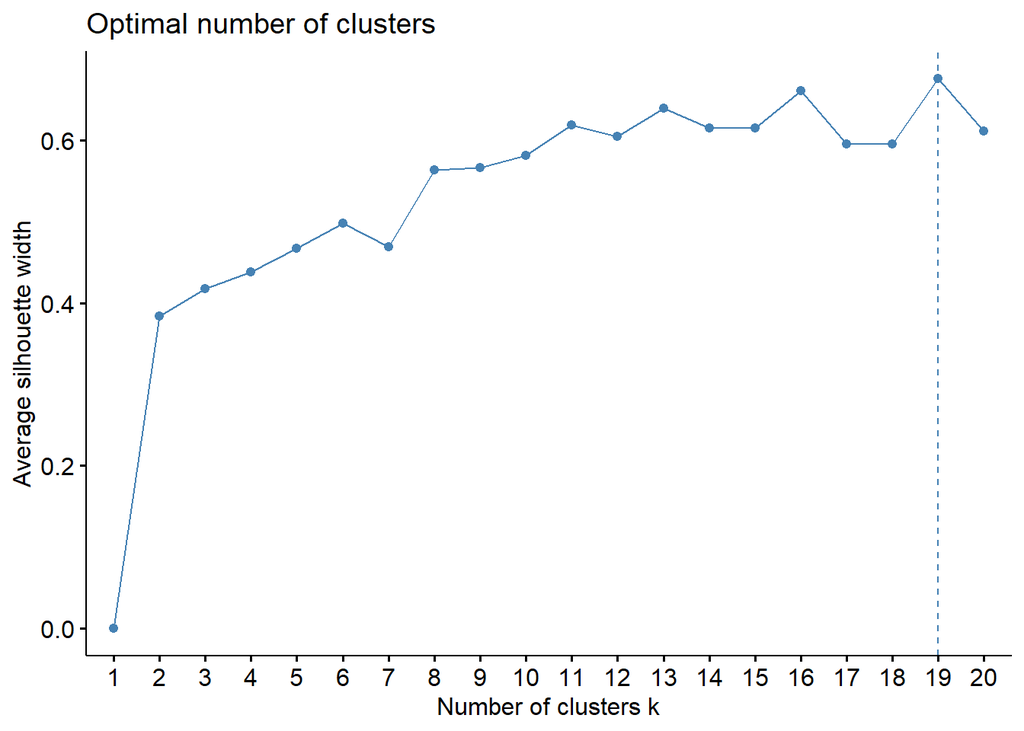

```r
fviz_nbclust(s1.scaled, kmeans, method = "silhouette", k.max = 20)
```

#### Finding the Optimal Number of Clusters with Silhouette Analysis

I calculated the average silhouette width across a range of cluster numbers (from 2 to 20) to further refine the optimal number of clusters. This custom approach provides a more precise insight into how well-separated the clusters are at each `k` value, complementing the initial silhouette method used with `fviz_nbclust`.

While `fviz_nbclust` suggested 19 clusters as optimal, this custom silhouette analysis indicated that 16 clusters yield the highest average silhouette width. The custom method gives finer control over the analysis, helping to confirm or narrow down the range from the initial method. Based on this analysis, 16 appears to be the most optimal number of clusters for this dataset. However, I will test out 15, 16, and 19 clusters to confirm which option provides the best clustering results.

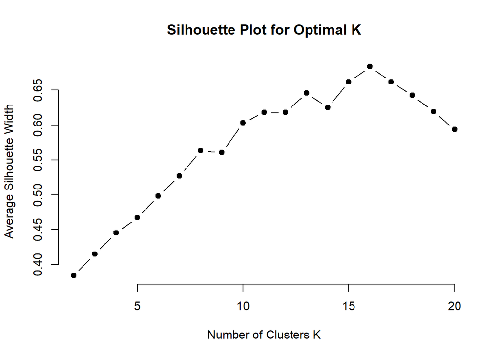

```r
library(cluster)

# Calculate average silhouette width for a range of cluster numbers
silhouette_avg <- function(k) {
  km <- kmeans(s1.scaled, centers = k, nstart = 10)
  ss <- silhouette(km$cluster, dist(s1.scaled))
  mean(ss[, 3])
}

sil_values <- sapply(2:20, silhouette_avg)

# Plot Silhouette values
plot(2:20, sil_values, type = "b", pch = 19, frame = FALSE,
     xlab = "Number of Clusters K", ylab = "Average Silhouette Width",
     main = "Silhouette Plot for Optimal K")
```

#### Evaluating K-Means Clustering with 15, 16, and 19 Clusters

In this step, I experimented with K-Means clustering using 15, 16, and 19 clusters, based on the initial visual analysis and silhouette findings. I created visualizations for each cluster count to evaluate how well K-Means captured the distinct groupings in the dataset.

Here’s what I observed:

Each plot demonstrates K-Means’ limitations with this dataset, underscoring how it may struggle to correctly group clusters due to its reliance on centroids and distance-based assumptions. This outcome highlights why DBSCAN, which doesn’t require predefined clusters or assume specific shapes, might better capture the natural groupings in this dataset.

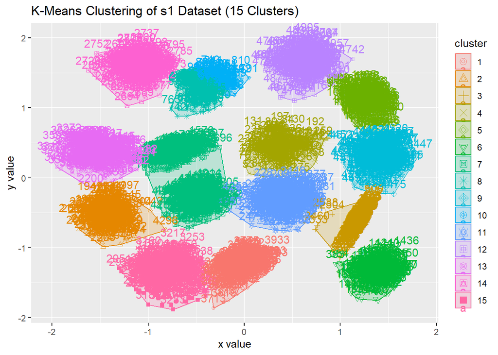

```r
km.s1.scaled <- kmeans(s1.scaled, 15, nstart = 10)
fviz_cluster(km.s1.scaled,
             s1,
             main = "K-Means Clustering of s1 Dataset (15 Clusters)")
```

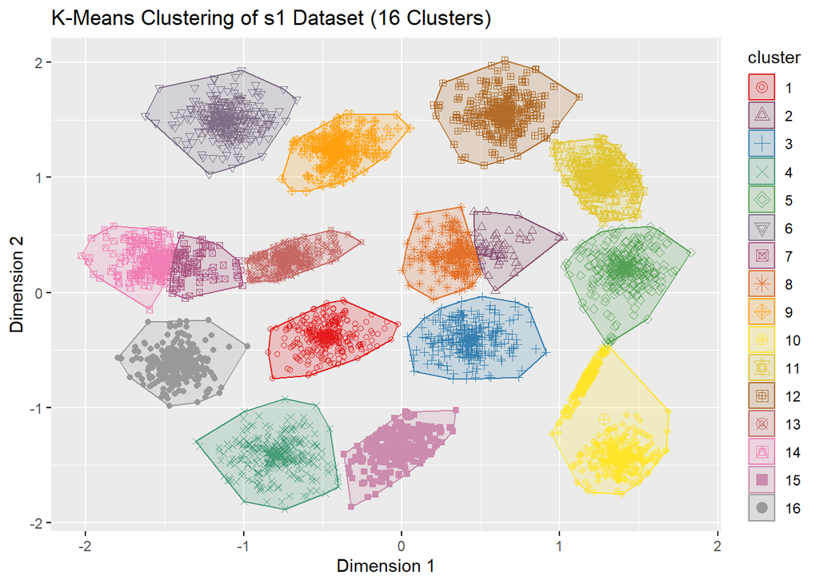

```r
my_colors <- colorRampPalette(brewer.pal(9, "Set1"))(16)

km.s1.scaled <- kmeans(s1.scaled, centers = 16, nstart = 10)

fviz_cluster(km.s1.scaled, data = s1.scaled,
             geom = "point",
             ellipse.type = "convex",
             main = "K-Means Clustering of s1 Dataset (16 Clusters)",
             xlab = "Dimension 1", ylab = "Dimension 2",
             palette = my_colors)
```

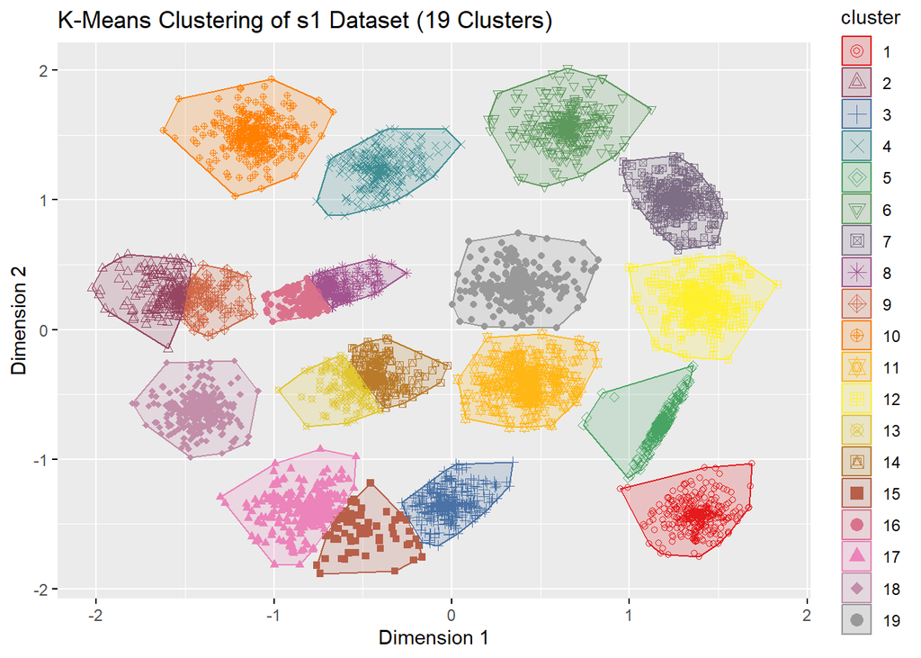

```r
my_colors <- colorRampPalette(brewer.pal(9, "Set1"))(19)

km.s1.scaled <- kmeans(s1.scaled, centers = 19, nstart = 10)

fviz_cluster(km.s1.scaled, data = s1.scaled,
             geom = "point",  # Use points for the plot
             ellipse.type = "convex",  # Add convex cluster shapes
             main = "K-Means Clustering of s1 Dataset (19 Clusters)",
             xlab = "Dimension 1", ylab = "Dimension 2",
             palette = my_colors)  # Use the custom color palette
```

#### Applying DBSCAN and Optimal Parameter Selection

To determine the best parameters for DBSCAN, I used a `kNNdistplot` with `k = 8`, which helped identify an optimal `eps` value of 0.095. Using these parameters—`eps = 0.095` and `MinPts = 8`—I ran DBSCAN on the scaled dataset.

DBSCAN performed exceptionally well, accurately separating the clusters into 15 distinct groups. Unlike K-Means, which struggled to distinguish some clusters or incorrectly split single clusters into two, DBSCAN successfully identified clusters that were visually distinct yet difficult to separate with other methods. This highlights DBSCAN’s strength in recognizing clusters of varying shapes and densities without the limitations imposed by centroid-based algorithms like K-Means.

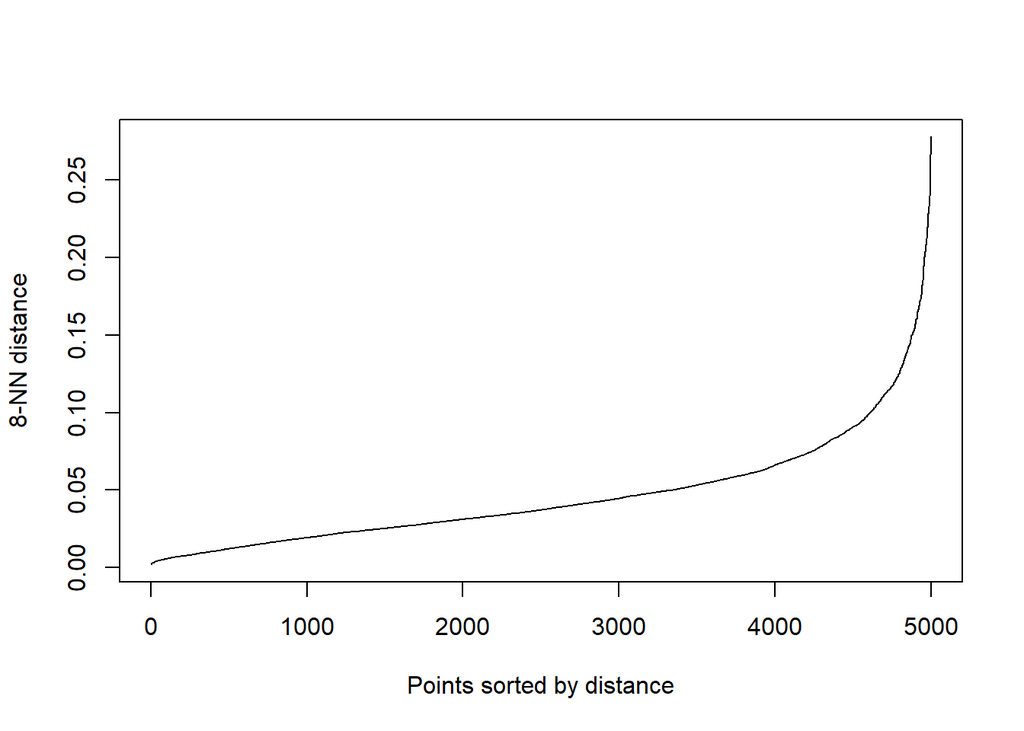

```r
kNNdistplot(s1.scaled, k = 8)
```

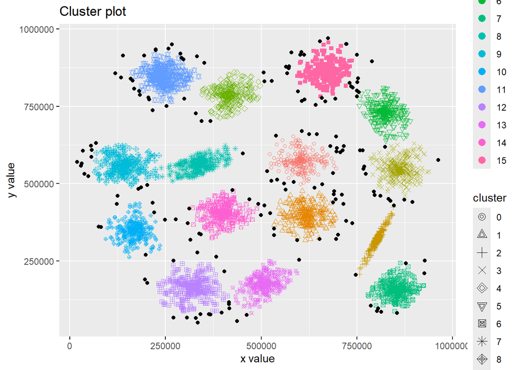

```r
dbscan.s1.scaled <- fpc::dbscan(s1.scaled, eps = 0.095, MinPts = 8)
fviz_cluster(dbscan.s1.scaled, s1, stand = FALSE, ellipse = F, geom = "point")
```